# Feature selection: crabs

Filters against a wrapper, on five measurements that are almost perfectly correlated and two different targets.

The other vignettes are listed by `vignette (package = "fdm2id")`; they use the same handful of functions on other data, and can be read in any order.

```r
library (fdm2id)
```

# The data

The `crabs` dataset of the `MASS` package, on *Leptograpsus variegatus* crabs collected at Fremantle, Australia. Two colour forms, orange and blue, and both sexes. Five measurements were taken on each individual (in mm): the size of the frontal lobe (`FL`), the rear width (`RW`), the length of the carapace (`CL`), its width (`CW`) and the depth of the body (`BD`).

There are two targets rather than one: the species (`sp`, `O` or `B`) and the sex (`sex`, `F` or `M`), with 50 males and 50 females of each species.

```r
data (crabs, package = "MASS")
summary (crabs)
```

```
#>  sp      sex         index            FL              RW              CL
#>  B:100   F:100   Min.   : 1.0   Min.   : 7.20   Min.   : 6.50   Min.   :14.70
#>  O:100   M:100   1st Qu.:13.0   1st Qu.:12.90   1st Qu.:11.00   1st Qu.:27.27
#>                  Median :25.5   Median :15.55   Median :12.80   Median :32.10
#>                  Mean   :25.5   Mean   :15.58   Mean   :12.74   Mean   :32.11
#>                  3rd Qu.:38.0   3rd Qu.:18.05   3rd Qu.:14.30   3rd Qu.:37.23
#>                  Max.   :50.0   Max.   :23.10   Max.   :20.20   Max.   :47.60
#>        CW              BD
#>  Min.   :17.10   Min.   : 6.10
#>  1st Qu.:31.50   1st Qu.:11.40
#>  Median :36.80   Median :13.90
#>  Mean   :36.41   Mean   :14.03
#>  3rd Qu.:42.00   3rd Qu.:16.60
#>  Max.   :54.60   Max.   :21.60
```

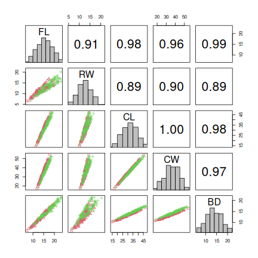

```r
plotdata (crabs [, 4:8], crabs [, 1], type = "pairs")
```

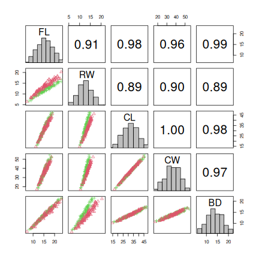

```r
plotdata (crabs [, 4:8], crabs [, 2], type = "pairs")
```

The five measurements are almost perfectly correlated with each other – a crab is simply bigger or smaller – so most of what any one of them says, the others say too. That is what makes the *selection* the interesting question here rather than the classifier.

```r
round (cor (crabs [, 4:8]), 3)
```

```
#>       FL    RW    CL    CW    BD
#> FL 1.000 0.907 0.979 0.965 0.988
#> RW 0.907 1.000 0.893 0.900 0.889
#> CL 0.979 0.893 1.000 0.995 0.983
#> CW 0.965 0.900 0.995 1.000 0.968
#> BD 0.988 0.889 0.983 0.968 1.000
```

# Question 1. Selecting for the species

Using a ranking algorithm and Fisher’s index as the univariate criterion, which multivariate criterion – the F statistic, mRMR, or a wrapper – gives the best predictions of the species with a naive Bayes classifier?

```r
# The two filters are deterministic; the wrapper is not -- it judges each subset by fitting a
# naive Bayes classifier under a bootstrap, so without 'seed' it can stop at a different
# subset from one run to the next. That is the criterion's own variance, not the data's.
s.fstat1 = selectfeatures (crabs [, 4:8], crabs [, 1], algorithm = "ranking",
                           unieval = "fisher", multieval = "fstat", seed = 0)
s.mrmr1 = selectfeatures (crabs [, 4:8], crabs [, 1], algorithm = "ranking",
                          unieval = "fisher", multieval = "mrmr", seed = 0)
s.wrap1 = selectfeatures (crabs [, 4:8], crabs [, 1], algorithm = "ranking",
                          unieval = "fisher", multieval = "wrapper", wrapmethod = NB,
                          seed = 0)
s.fstat1
```

```
#> Feature selection
#>   algorithm              : ranking
#>   univariate criterion   : fisher
#>   multivariate criterion : fstat
#>   features kept          : 1: FL
#>   score                  : 46.99
```

```r
s.mrmr1
```

```
#> Feature selection
#>   algorithm              : ranking
#>   univariate criterion   : fisher
#>   multivariate criterion : mrmr
#>   features kept          : 1: FL
#>   score                  : 0.1974
```

```r
s.wrap1
```

```
#> Feature selection
#>   algorithm              : ranking
#>   univariate criterion   : fisher
#>   multivariate criterion : wrapper
#>   features kept          : 1: FL
#>   score                  : 0.6779
```

```r
performance (NB, crabs [, 4:8], crabs [, 1], nruns = 100, seed = 0)
```

```
#>  accuracy
#> 0.6191188
```

```r
performance (NB, crabs [, 4:8] [, s.fstat1$selection], crabs [, 1], nruns = 100, seed = 0)
```

```
#>  accuracy
#> 0.6626326
```

```r
performance (NB, crabs [, 4:8] [, s.mrmr1$selection], crabs [, 1], nruns = 100, seed = 0)
```

```
#>  accuracy
#> 0.6626326
```

```r
performance (NB, crabs [, 4:8] [, s.wrap1$selection], crabs [, 1], nruns = 100, seed = 0)
```

```
#>  accuracy
#> 0.6626326
```

**Answer.** *All three criteria stop at the same subset and therefore give the same performance – which is better than using all five variables. Adding correlated measurements to a naive Bayes classifier, whose whole assumption is that they are independent, costs accuracy.*

# Question 2. Selecting for the sex

The same question, for the sex of the crabs.

```r
s.fstat2 = selectfeatures (crabs [, 4:8], crabs [, 2], algorithm = "ranking",
                           unieval = "fisher", multieval = "fstat", seed = 0)
s.mrmr2 = selectfeatures (crabs [, 4:8], crabs [, 2], algorithm = "ranking",
                          unieval = "fisher", multieval = "mrmr", seed = 0)
s.wrap2 = selectfeatures (crabs [, 4:8], crabs [, 2], algorithm = "ranking",
                          unieval = "fisher", multieval = "wrapper", wrapmethod = NB,
                          seed = 0)
s.fstat2
```

```
#> Feature selection
#>   algorithm              : ranking
#>   univariate criterion   : fisher
#>   multivariate criterion : fstat
#>   features kept          : 1: RW
#>   score                  : 18.4
```

```r
s.mrmr2
```

```
#> Feature selection
#>   algorithm              : ranking
#>   univariate criterion   : fisher
#>   multivariate criterion : mrmr
#>   features kept          : 1: RW
#>   score                  : 0.1264
```

```r
s.wrap2
```

```
#> Feature selection
#>   algorithm              : ranking
#>   univariate criterion   : fisher
#>   multivariate criterion : wrapper
#>   features kept          : 3: RW, CL, BD
#>   score                  : 0.7358
```

```r
performance (NB, crabs [, 4:8], crabs [, 2], nruns = 100, seed = 0)
```

```
#>  accuracy
#> 0.6624966
```

```r
performance (NB, crabs [, 4:8] [, s.fstat2$selection], crabs [, 2], nruns = 100, seed = 0)
```

```
#>  accuracy
#> 0.6236062
```

```r
performance (NB, crabs [, 4:8] [, s.mrmr2$selection], crabs [, 2], nruns = 100, seed = 0)
```

```
#>  accuracy
#> 0.6236062
```

```r
performance (NB, crabs [, 4:8] [, s.wrap2$selection], crabs [, 2], nruns = 100, seed = 0)
```

```
#>  accuracy
#> 0.7129453
```

**Answer.** *Only the wrapper improves on the full set of variables. The two filter criteria stop at a single variable and lose accuracy – which is the trade-off of the family: a filter judges a subset without ever fitting the model it is selecting for, and here that judgement is wrong.*

# Question 3. Which variables, in the end?

```r
colnames (crabs) [4:8] [s.fstat1$selection]
```

```
#> [1] "FL"
```

```r
colnames (crabs) [4:8] [s.wrap2$selection]
```

```
#> [1] "RW" "CL" "BD"
```

**Answer.** *The frontal lobe alone is what distinguishes the two species; distinguishing the sexes takes three measurements – the rear width, the length of the carapace and the depth of the body. Two different questions asked of the same five measurements, and two different answers.*